# L16

# Approximate Inference Queries

## Sampling

- A lot like repeated simulation
- Basic Idea
  1. Draw $N$ samples from a sampling distribution $S$
  2. Compute an approximate posterior probability
  3. Show this converges to the true probability $P$

### Sampling from a Given Distribution

1. Get sample $u$ from uniform distribution over $[0,1)$ (use PRNG or something)
2. Convert this sample $u$ into an outcome for the given distribution by having each target outcome associated with a sub-interval of $[0,1)$ with sub-interval size equal to probability of the outcome
- eg:

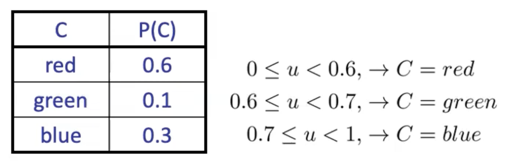

## Prior Sampling

- Sample topologically in order of bayes net
- All sub-samples taken given the parents
- Return $(x_{1},x_{2},{\dots},x_{n})\,|\,x_{i}\coloneqq\mathrm{sample}(x_{i},\mathbb{P}(X_{i}\,|\,\mathrm{parents}(X_{i})))$
- Generates samples with probability $S_{PS}(x_{1},{\dots},x_{n})=\prod_{i=1}^{n}\mathbb{P}(x_{i}\;|\;\mathrm{parents}(X_{i}))$
  - Same as $\mathbb{P}(x_{1},{\dots},x_{n})$
  - The probability of a sample is equal to the probability of the sample in the joint distribution
- $$\lim_{n\to\infty}\hat{P}(x_{1},{\dots},x_{n})=\frac{\lim_{n\to\infty}N_{PS}(x_{1},{\dots},x_{n})}{N}=S_{PS}(x_{1},{\dots},x_{n})=\mathbb{P}(x_{1},{\dots},x_{n})$$
  - $N_{PS}\coloneqq\text{number of samples of an event}$
  - Basically as your samples increase, you get more accurate
- Consistent ≔ the samples match the frequencies in the joint distribution
- To get the probability from the samples, you normalize the counts for the variable you’re looking for
- Good because you can estimate any probability in the BN given the samples
- Good because you can choose the amount of samples you want to take
- If you don’t have any samples for something, you don’t know what it is and need more samples (no answer)
  - Bad if evidence is rare

## Rejection Sampling

- Like prior sampling
- Just keep a count of the amount of times things show up
  - Means you don’t have to maintain a long list of samples
- If there is a given (evidence provided) and the sample does not fulfill the evidence, then ignore the sample and do not add it to the counts
- Bad if evidence is rare
- Consistent

## Likelihood Weighting

- Fix evidence variables and sample the rest
- Problem: sample distribution is not consistent
- Solution: weight by probability of evidence given parents
  - Each sample also has a weight
  - Weight is initially 1 and then multiplied by the weights of the fixed variables in the sample
- Sample Values:
  $$\left.S_{WS}(z,e)\coloneqq\prod_{i=1}^{l}\mathbb{P}(z_{i}\,|\,\mathrm{parents}(Z_{i}))\,\right|\,_{\begin{array}{l}
  z\;\coloneqq\;\text{sampled values} \\
  e\;\coloneqq\;\text{evidence values fixed} \\
  l\;\coloneqq\;\text{number of samples retained}
  \end{array}}$$
- Sample weights:
  $$\left.w(z,e)\coloneqq\prod_{i=1}^{m}\mathbb{P}(e_{i}\,|\,\mathrm{parents}(E_{i}))\right|_{m\;\coloneqq\;\text{number
  of samples 'rigged'}}$$
- Weighted sampling distribution is consistent:
  $$S_{WS}(z,e)*w(z,e)=\prod_{i=1}^{l}\mathbb{P}(z_{i}\,|\,\mathrm{parents}(z_{i}))\prod_{i=1}^{m}\mathbb{P}(e_{i\,|\,\mathrm{parents}(e_{i})})$$
- Good when evidence is at the top of the BN
  - Generally lower weight the further ‘downstream’ something is in a BN
  - Evidence influences the choice of downstream variables, but not upstream ones

## Gibbs Sampling

- Mostly not required to know
- Keep track of a full instantiation of $x_{1},x_{2},{\dots},x_{n}$. Start with an arbitrary instantiation consistent with the evidence. Sample one variable at a time, conditioned on all the rest, but keep evidence fixed. Keep repeating this for a long time.
- In the limit of repeating this infinitely many times, the resulting samples come from the correct distribution
- Both upstream and downstream variables condition on evidence
  - Have to compute the cost of all non-fixed elements conditioned on every other element

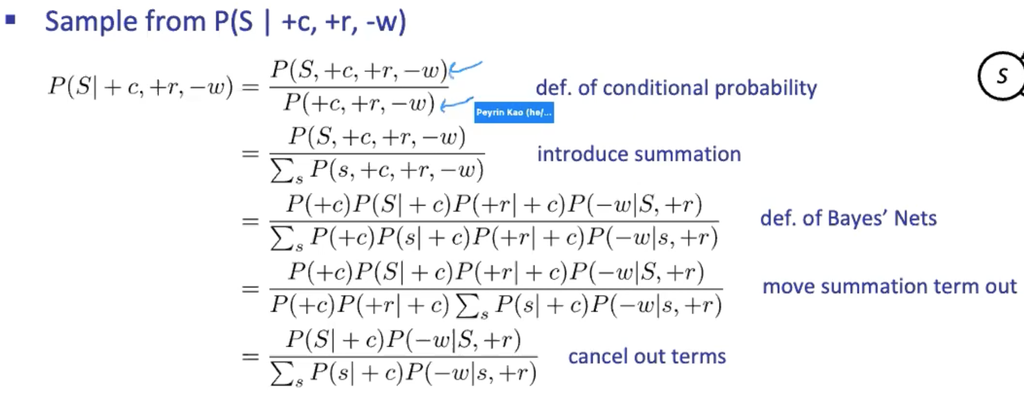

    - **Note**: Only need to consider CPTs with $S$ remain